# MatePrefsIrisW.

Iris Whetstone

2026-10-21

#### Data Wrangling

H1: Respondents with doctoral or equivalent professional degrees will have lower relationship satisfaction in their relationships.

H2: Male respondents who spend a lot of time grooming their hair daily will also report a lot of time spent on social media daily.

## Load package and data

```r
# load the codeook package

library(codebook)

#load data

raw <- read.csv("raw/data_doctored.csv")

# check row and column counts and inspect the first few rows

dim(raw)
```

```
## [1] 117294    273
```

```r
str(raw)
```

```
## 'data.frame':    117294 obs. of  273 variables:
##  $ StartDate                    : chr  "2021-04-08 11:20:10" "2021-04-08 11:24:41" "2021-04-08 18:26:26" "2021-04-08 18:36:18" ...
##  $ EndDate                      : chr  "2021-04-08 11:24:37" "2021-04-08 12:23:55" "2021-04-08 18:49:16" "2021-04-08 18:57:04" ...
##  $ Progress                     : int  100 100 100 100 100 100 100 100 100 100 ...
##  $ Duration..in.seconds.        : int  267 3554 1369 1245 2036 4248 5031 5502 1756 511 ...
##  $ Finished                     : int  1 1 1 1 1 1 1 1 1 1 ...
##  $ RecordedDate                 : chr  "2021-04-08 11:24:39" "2021-04-08 12:23:57" "2021-04-08 18:49:17" "2021-04-08 18:57:05" ...
##  $ ResponseId                   : chr  "R_2xXVnjIygWO0Di0" "R_Zkpb4Zwe8xxHudX" "R_cT3y280tkqdqfVD" "R_0AlgoZdEoW9j7zz" ...
##  $ UserLanguage                 : chr  "UK" "UK" "EN" "EN" ...
##  $ Consent                      : int  1 1 1 1 1 1 1 1 1 1 ...
##  $ Sex                          : int  1 NA 0 0 0 0 1 0 1 0 ...
##  $ Sex_birth                    : int  NA NA NA NA NA NA NA NA NA NA ...
##  $ Age                          : int  33 35 26 33 27 32 27 27 31 33 ...
##  $ Country_raised               : chr  NA NA "Nigeria" "Nigeria" ...
##  $ Country_live                 : int  NA NA 128 139 10 128 128 128 128 185 ...
```

[output cut: 86 more lines]

```r
# make data with ID, level of education, perceived warm, perceived understanding, percieved magic, perceived passion, time spent grooming hair, and time spent on social media

data <- raw[,c("ResponseId","cot_educ", "Relationship_status", "Love_1","Love_5","Love_9","Love_10", "Time_A_hair_1","Time_social_media_1", "Sex_birth")]

dim(data)
```

```
## [1] 117294     10
```

```r
str(data)
```

```
## 'data.frame':    117294 obs. of  10 variables:
##  $ ResponseId         : chr  "R_2xXVnjIygWO0Di0" "R_Zkpb4Zwe8xxHudX" "R_cT3y280tkqdqfVD" "R_0AlgoZdEoW9j7zz" ...
##  $ cot_educ           : int  NA NA 5 6 6 6 5 5 5 NA ...
##  $ Relationship_status: int  2 NA 0 2 3 2 2 0 3 1 ...
##  $ Love_1             : int  NA NA NA 4 4 4 3 NA 1 NA ...
##  $ Love_5             : int  NA NA NA 3 3 5 3 NA 1 NA ...
##  $ Love_9             : int  NA NA NA 3 4 2 3 NA 1 NA ...
##  $ Love_10            : int  NA NA NA 3 4 4 NA NA 1 NA ...
##  $ Time_A_hair_1      : int  NA NA 7 12 4 30 30 343 360 NA ...
##  $ Time_social_media_1: int  NA NA 180 59 120 360 90 180 360 239 ...
##  $ Sex_birth          : int  NA NA NA NA NA NA NA NA NA NA ...
```

## 2. Check participant IDs

```r
#count nas, blanks, and duplicates

summary(data$ResponseId)
```

```
##    Length  N.unique   N.blank Min.nchar Max.nchar       NAs
##    117294    117293         0        17        18         1
```

```r
#inspect records with missing or blank IDs

missingID <- which(is.na(data$ResponseId))
print(data[missingID,])
```

```
##        ResponseId cot_educ Relationship_status Love_1 Love_5 Love_9 Love_10
## 117294       <NA>       NA                  NA     NA     NA     NA      NA
##        Time_A_hair_1 Time_social_media_1 Sex_birth
## 117294            NA                  NA        NA
```

```r
#remove the known empty record with no ID, then check the row count
data <- data[!is.na(data$ResponseId),]
```

[output not shown]

## 3. Recode Education Level and Relationship Satisfaction

```r
## create relLove for participants currently in relationships

# codebook: 1,2,3 indicate participants currently in relationships

relLove <- raw[raw$Relationship_status %in% c(1, 2, 3), ]

## recode education level

# examine initial data

table(relLove$cot_educ, useNA = "ifany")
```

```
##
##     1     2     3     4     5     6     7  <NA>
##   151   273  2770 11024 21746 11977  3700 13119
```

```r
# change education level to factor labels

relLove$cot_educ <- factor(
  relLove$cot_educ,
  levels = 1:7,
  labels = c("None", "Primary", "Secondary", "HighSchoolorTech",
             "Bachelor", "Master", "PhDorEq")
)

# check to see if it worked

table(relLove$cot_educ, useNA = "ifany")
```

```
##
##             None          Primary        Secondary HighSchoolorTech
##              151              273             2770            11024
##         Bachelor           Master          PhDorEq             <NA>
##            21746            11977             3700            13119
```

```r
# create two groups for comparison and other levels of education

relLove$degreeGroup <- factor(
  ifelse(relLove$cot_educ == "PhDorEq", "Doctoral/professional", "Other education")
)

# check to see if it worked

table(relLove$degreeGroup, useNA = "ifany")
```

```
##
## Doctoral/professional       Other education                  <NA>
##                  3700                 47941                 13119
```

```r
## recode relationship satisfaction

# define satisfaction items

satVars <- c("prqc_1", "prqc_2", "prqc_3")

# inspect range of satisfaction items (1-7)

summary(relLove[, satVars])
```

```
##      prqc_1          prqc_2          prqc_3
##  Min.   :1.00    Min.   :1.000   Min.   :1.000
##  1st Qu.:5.00    1st Qu.:5.000   1st Qu.:5.000
##  Median :6.00    Median :6.000   Median :6.000
##  Mean   :5.53    Mean   :5.574   Mean   :5.664
##  3rd Qu.:7.00    3rd Qu.:7.000   3rd Qu.:7.000
##  Max.   :7.00    Max.   :7.000   Max.   :7.000
##  NAs    :13865   NAs    :13871   NAs    :13851
```

```r
# compute composite score

relLove$relSat <- rowMeans(relLove[, satVars], na.rm = TRUE)

# replace unusable data (3/3 NA)

relLove$relSat[is.nan(relLove$relSat)] <- NA

# check to see if composite score is normal

summary(relLove$relSat)
```

```
##    Min. 1st Qu.  Median    Mean 3rd Qu.    Max.     NAs
##   1.000   5.000   6.000   5.588   6.667   7.000   13691
```

```r
# define h1 data

h1Data <- relLove[!is.na(relLove$relSat) & !is.na(relLove$degreeGroup),
                  c("ResponseId", "cot_educ",  "degreeGroup", "relSat")
]

# make sure it worked

dim(h1Data)
```

```
## [1] 50950     4
```

```r
summary(h1Data)
```

```
##      ResponseId                cot_educ                    degreeGroup
##  Length   :50950   None            :  143   Doctoral/professional: 3636
##  N.unique :50950   Primary         :  268   Other education      :47314
##  N.blank  :    0   Secondary       : 2727
##  Min.nchar:   17   HighSchoolorTech:10883
##  Max.nchar:   18   Bachelor        :21468
##                    Master          :11825
##                    PhDorEq         : 3636
##      relSat
##  Min.   :1.000
##  1st Qu.:5.000
##  Median :6.000
##  Mean   :5.588
##  3rd Qu.:6.667
##  Max.   :7.000
##
```

```r
table(h1Data$degreeGroup, useNA = "ifany")
```

```
##
## Doctoral/professional       Other education
##                  3636                 47314
```

## Recode Time Spent on Hair and Social Media

```r
## Recode sex at birth

# view

table(data$Sex_birth,useNA="ifany")
```

```
##
##     0     1     2  <NA>
## 34859 72026   188 10220
```

```r
# turn Sex_birth into a factor with proper labels

data$Sex_birth <- factor(data$Sex_birth,
                         levels = c(0,1,2),
                         labels = c("Male","Female","Intersex"))

# create maleData

maleData <- data[data$Sex_birth == "Male" & !is.na(data$Sex_birth), ]

#define the minutes to check that both use 0-360 minutes

mins <- c("Time_social_media_1","Time_A_hair_1")

#check the summaries and missing responses

summary(maleData[,mins])
```

```
##  Time_social_media_1 Time_A_hair_1
##  Min.   :  0.0       Min.   :  0.00
##  1st Qu.: 60.0       1st Qu.:  7.00
##  Median :119.0       Median : 15.00
##  Mean   :130.8       Mean   : 36.86
##  3rd Qu.:180.0       3rd Qu.: 31.00
##  Max.   :360.0       Max.   :360.00
##  NAs    :145         NAs    :11260
```

```r
colSums(is.na(maleData[,mins]))
```

```
## Time_social_media_1       Time_A_hair_1
##                 145               11260
```

```r
#inspect the response frequencies for each item

for(i in mins){
  print(i)
  print(table(maleData[,i],useNA="ifany"))
}
```

```
## [1] "Time_social_media_1"
##
##    0    1    2    3    4    5    6    7    8    9   10   11   12   13   14   15
##  928   62   51   44   36  212   33   18   28   31  427   40   41   25   42  374
##   16   17   18   19   20   21   22   23   24   25   26   27   28   29   30   31
##   62   25   30   47  491   57   45   24   47   98   41   33   52  118 1321  165
##   32   33   34   35   36   37   38   39   40   41   42   43   44   45   46   47
##   94   71   53  119   63   43   49   40  356   74   59   51   67  434  105   45
##   48   49   50   51   52   53   54   55   56   57   58   59   60   61   62   63
##   43   58  205   70   44   51   47   97   65   73  116  228 2790  524  185  142
##   64   65   66   67   68   69   70   71   72   73   74   75   76   77   78   79
##   83   98   83   66   51   70   99   68   61   57   67  177   71   50   54   54
##   80   81   82   83   84   85   86   87   88   89   90   91   92   93   94   95
##  170   81   45   55   54   91   64   70  105  166 1525  289  144   83   79   85
##   96   97   98   99  100  101  102  103  104  105  106  107  108  109  110  111
```

[output cut: 91 more lines]

```r
#replace any codes outside 0-360 with NA

for(i in mins){
maleData[,i] <- ifelse(maleData[,i] >= 0 & maleData[,i] <= 360, maleData[,i], NA)
}

# define h2 data

h2Data <- maleData[
!is.na(maleData$Time_social_media_1) & !is.na(maleData$Time_A_hair_1),
c("ResponseId", "Sex_birth", "Time_A_hair_1", "Time_social_media_1")
]

#make sure it worked and is only using male data

dim(h2Data)
```

```
## [1] 23583     4
```

```r
colnames(h2Data)
```

```
## [1] "ResponseId"          "Sex_birth"           "Time_A_hair_1"
## [4] "Time_social_media_1"
```

```r
table(h2Data$Sex_birth, useNA = "always")
```

```
##
##     Male   Female Intersex     <NA>
##    23583        0        0        0
```

## 7. Check the final tables

```r
#check rows, columns, types, and missing values in h1Data, make sure scores are between 1-7

dim(h1Data)
```

```
## [1] 50950     4
```

```r
str(h1Data)
```

```
## 'data.frame':    50950 obs. of  4 variables:
##  $ ResponseId : chr  "R_0AlgoZdEoW9j7zz" "R_ywofOySqhAk7B8B" "R_3dSvB2ekd3flXL7" "R_1eseCMqQp7tP5V3" ...
##  $ cot_educ   : Factor w/ 7 levels "None","Primary",..: 6 6 6 5 5 6 5 6 6 5 ...
##  $ degreeGroup: Factor w/ 2 levels "Doctoral/professional",..: 2 2 2 2 2 2 2 2 2 2 ...
##  $ relSat     : num  4.5 5.33 5 6 1.67 ...
```

```r
head(h1Data)
```

```
##           ResponseId cot_educ     degreeGroup   relSat
## 4  R_0AlgoZdEoW9j7zz   Master Other education 4.500000
## 5  R_ywofOySqhAk7B8B   Master Other education 5.333333
## 6  R_3dSvB2ekd3flXL7   Master Other education 5.000000
## 7  R_1eseCMqQp7tP5V3 Bachelor Other education 6.000000
## 9  R_1pMzbPAIAsfMjkD Bachelor Other education 1.666667
## 11 R_2BfegjDltLNwGKA   Master Other education 6.000000
```

```r
colSums(is.na(h1Data))
```

```
##  ResponseId    cot_educ degreeGroup      relSat
##           0           0           0           0
```

```r
table(h1Data$cot_educ,useNA="ifany")
```

```
##
##             None          Primary        Secondary HighSchoolorTech
##              143              268             2727            10883
##         Bachelor           Master          PhDorEq
##            21468            11825             3636
```

```r
range(h1Data$satVars)
```

```
## [1]  Inf -Inf
```

```r
sum(duplicated(h1Data$ResponseId))
```

```
## [1] 0
```

```r
#repeat the checks for h2Data; both scores should be within 0-360

dim(h2Data)
```

```
## [1] 23583     4
```

```r
str(h2Data)
```

```
## 'data.frame':    23583 obs. of  4 variables:
##  $ ResponseId         : chr  "R_RlSDIrHiQFolIgF" "R_2v6zZmwfInsBwpP" "R_XZz8FmNFgdr1Du9" "R_28D4n3sGZkxIfXs" ...
##  $ Sex_birth          : Factor w/ 3 levels "Male","Female",..: 1 1 1 1 1 1 1 1 1 1 ...
##  $ Time_A_hair_1      : int  73 3 15 0 47 217 43 5 24 15 ...
##  $ Time_social_media_1: int  75 120 123 180 267 72 130 61 121 240 ...
```

```r
head(h2Data)
```

```
##           ResponseId Sex_birth Time_A_hair_1 Time_social_media_1
## 14 R_RlSDIrHiQFolIgF      Male            73                  75
## 17 R_2v6zZmwfInsBwpP      Male             3                 120
## 19 R_XZz8FmNFgdr1Du9      Male            15                 123
## 21 R_28D4n3sGZkxIfXs      Male             0                 180
## 24 R_3NHQSWmXvLakHhW      Male            47                 267
## 26 R_1BWnMWgJaDCZy0I      Male           217                  72
```

```r
colSums(is.na(h2Data))
```

```
##          ResponseId           Sex_birth       Time_A_hair_1 Time_social_media_1
##                   0                   0                   0                   0
```

```r
range(h2Data$Time_social_media_1)
```

```
## [1]   0 360
```

```r
range(h2Data$Time_A_hair_1)
```

```
## [1]   0 360
```

```r
sum(duplicated(h2Data$ResponseId))
```

```
## [1] 0
```

## 8. Add labels and generate codebooks

```r
#add a description to each h1Data column, in column order, include the source codes, meaning, and units

var_label(h1Data) <- c(
  "Unique participant ID (ResponseId)",
  "Level of education: all valid responses for level of education categorized as None, Primary, Secondary, HighSchoolorTech, Bachelor, Master, PhDorEq",
  "Doctoral/profession or other: degreeGroup categorized as all valid Doctoral/professional responses or Other education (any other level of education) responses",
  "Relationship satisfaction: labeled relSat, mean of available prqc_1-3 responses, each 1=Not at all to 7=Extremely; no reverse coding; at least one valid response required"
)

#add a description to each h2Data column, in column order
#include response anchors and the commitment scoring rule

var_label(h2Data) <- c(
  "Unique participant ID (ResponseId)",
  "Sex at birth: labeled Sex_birth, displays all male data",
  "Time spent on grooming hair: labled Time_A_hair_1, all valid responses reporting daily time spent grooming hair between 0-360 minutes",
  "Time spent on social media: labeled Time_social_media_1, all valid responses reporting daily time spent on social media between 0-360 minutes"
)
```

The descriptions come from the original codebook and our scoring decisions. `compact_codebook()` adds summaries from the actual data. Knit the Rmd to display the formatted codebooks.

H1 includes participants with an ID, relationship status 1, 2, or 3, and at least one of three non-missing scores between 1-7 Likert-type scales. Factor level numbers in the generated table are internal R positions, not the original survey codes.

```r
# generate h2Data codebook

compact_codebook(h1Data)
```

### Metadata

#### Description

**Dataset name**: results

The dataset has N=50950 rows and 4 columns. 50950 rows have no missing values on any column.

**Metadata for search engines**

- **Date published**: 2026-11-10

| name | value |
| --- | --- |
| keywords | ResponseId, cot_educ, degreeGroup, relSat |

## Codebook table

| name | label | data_type | ordered | value_labels | n_missing | complete_rate | n_unique | empty | top_counts | min | median | max | mean | sd | whitespace | hist |
| --- | --- | --- | --- | --- | --- | --- | --- | --- | --- | --- | --- | --- | --- | --- | --- | --- |
| ResponseId | Unique participant ID (ResponseId) | character | NA | NA | 0 | 1 | 50950 | 0 | NA | 17 | NA | 18 | NA | NA | 0 | NA |
| cot_educ | Level of education: all valid responses for level of education categorized as None, Primary, Secondary, HighSchoolorTech, Bachelor, Master, PhDorEq | factor | FALSE | 1. None, 2. Primary, 3. Secondary, 4. HighSchoolorTech, 5. Bachelor, 6. Master, 7. PhDorEq | 0 | 1 | 7 | NA | Bac: 21468, Mas: 11825, Hig: 10883, PhD: 3636 | NA | NA | NA | NA | NA | NA | NA |
| degreeGroup | Doctoral/profession or other: degreeGroup categorized as all valid Doctoral/professional responses or Other education (any other level of education) responses | factor | FALSE | 1. Doctoral/professional, 2. Other education | 0 | 1 | 2 | NA | Oth: 47314, Doc: 3636 | NA | NA | NA | NA | NA | NA | NA |
| relSat | Relationship satisfaction: labeled relSat, mean of available prqc_1-3 responses, each 1=Not at all to 7=Extremely; no reverse coding; at least one valid response required | numeric | NA | NA | 0 | 1 | NA | NA | NA | 1 | 6 | 7 | 5.587887 | 1.395453 | NA | ▁▁▂▃▇ |

**JSON-LD metadata**

The following JSON-LD can be found by search engines, if you share this codebook publicly on the web.

```json
{
  "name": "results",
  "datePublished": "2026-11-10",
  "description": "The dataset has N=50950 rows and 4 columns.\n50950 rows have no missing values on any column.\n\n\n## Table of variables\nThis table contains variable names, labels, and number of missing values.\nSee the complete codebook for more.\n\n|name        |label                                                                                                                                                                      | n_missing|\n|:-----------|:--------------------------------------------------------------------------------------------------------------------------------------------------------------------------|---------:|\n|ResponseId  |Unique participant ID (ResponseId)                                                                                                                                         |         0|\n|cot_educ    |Level of education: all valid responses for level of education categorized as None, Primary, Secondary, HighSchoolorTech, Bachelor, Master, PhDorEq                        |         0|\n|degreeGroup |Doctoral/profession or other: degreeGroup categorized as all valid Doctoral/professional responses or Other education (any other level of education) responses             |         0|\n|relSat      |Relationship satisfaction: labeled relSat, mean of available prqc_1-3 responses, each 1=Not at all to 7=Extremely; no reverse coding; at least one valid response required |         0|\n\n### Note\nThis dataset was automatically described using the [codebook R package](https://rubenarslan.github.io/codebook/) (version 0.10.1).",
  "keywords": ["ResponseId", "cot_educ", "degreeGroup", "relSat"],
  "@context": "https://schema.org/",
  "@type": "Dataset",
  "variableMeasured": [
    {
      "name": "ResponseId",
      "description": "Unique participant ID (ResponseId)",
      "@type": "propertyValue"
    },
    {
      "name": "cot_educ",
      "description": "Level of education: all valid responses for level of education categorized as None, Primary, Secondary, HighSchoolorTech, Bachelor, Master, PhDorEq",
      "value": "1. None,\n2. Primary,\n3. Secondary,\n4. HighSchoolorTech,\n5. Bachelor,\n6. Master,\n7. PhDorEq",
      "@type": "propertyValue"
    },
    {
      "name": "degreeGroup",
      "description": "Doctoral/profession or other: degreeGroup categorized as all valid Doctoral/professional responses or Other education (any other level of education) responses",
      "value": "1. Doctoral/professional,\n2. Other education",
      "@type": "propertyValue"
    },
    {
      "name": "relSat",
      "description": "Relationship satisfaction: labeled relSat, mean of available prqc_1-3 responses, each 1=Not at all to 7=Extremely; no reverse coding; at least one valid response required",
      "@type": "propertyValue"
    }
  ]
}`
```

H2 includes participants with an ID, a valid sex-at-birth category, and both a valid nonmissing responses for time spent on grooming hair and social media between 0-360 minutes.

```r
#generate h2Data codebook

compact_codebook(h2Data)
```

### Metadata

#### Description

**Dataset name**: results

The dataset has N=23583 rows and 4 columns. 23583 rows have no missing values on any column.

**Metadata for search engines**

- **Date published**: 2026-11-10

| name | value |
| --- | --- |
| keywords | ResponseId, Sex_birth, Time_A_hair_1, Time_social_media_1 |

## Codebook table

| name | label | data_type | ordered | value_labels | n_missing | complete_rate | n_unique | empty | top_counts | min | median | max | mean | sd | whitespace | hist |
| --- | --- | --- | --- | --- | --- | --- | --- | --- | --- | --- | --- | --- | --- | --- | --- | --- |
| ResponseId | Unique participant ID (ResponseId) | character | NA | NA | 0 | 1 | 23583 | 0 | NA | 17 | NA | 18 | NA | NA | 0 | NA |
| Sex_birth | Sex at birth: labeled Sex_birth, displays all male data | factor | FALSE | 1. Male, 2. Female, 3. Intersex | 0 | 1 | 1 | NA | Mal: 23583, Fem: 0, Int: 0 | NA | NA | NA | NA | NA | NA | NA |
| Time_A_hair_1 | Time spent on grooming hair: labled Time_A_hair_1, all valid responses reporting daily time spent grooming hair between 0-360 minutes | numeric | NA | NA | 0 | 1 | NA | NA | NA | 0 | 15 | 360 | 36.83391 | 63.11982 | NA | ▇▁▁▁▁ |
| Time_social_media_1 | Time spent on social media: labeled Time_social_media_1, all valid responses reporting daily time spent on social media between 0-360 minutes | numeric | NA | NA | 0 | 1 | NA | NA | NA | 0 | 120 | 360 | 134.85948 | 97.87706 | NA | ▇▇▅▂▂ |

**JSON-LD metadata**

The following JSON-LD can be found by search engines, if you share this codebook publicly on the web.

```json
{
  "name": "results",
  "datePublished": "2026-11-10",
  "description": "The dataset has N=23583 rows and 4 columns.\n23583 rows have no missing values on any column.\n\n\n## Table of variables\nThis table contains variable names, labels, and number of missing values.\nSee the complete codebook for more.\n\n|name                |label                                                                                                                                         | n_missing|\n|:-------------------|:---------------------------------------------------------------------------------------------------------------------------------------------|---------:|\n|ResponseId          |Unique participant ID (ResponseId)                                                                                                            |         0|\n|Sex_birth           |Sex at birth: labeled Sex_birth, displays all male data                                                                                       |         0|\n|Time_A_hair_1       |Time spent on grooming hair: labled Time_A_hair_1, all valid responses reporting daily time spent grooming hair between 0-360 minutes         |         0|\n|Time_social_media_1 |Time spent on social media: labeled Time_social_media_1, all valid responses reporting daily time spent on social media between 0-360 minutes |         0|\n\n### Note\nThis dataset was automatically described using the [codebook R package](https://rubenarslan.github.io/codebook/) (version 0.10.1).",
  "keywords": ["ResponseId", "Sex_birth", "Time_A_hair_1", "Time_social_media_1"],
  "@context": "https://schema.org/",
  "@type": "Dataset",
  "variableMeasured": [
    {
      "name": "ResponseId",
      "description": "Unique participant ID (ResponseId)",
      "@type": "propertyValue"
    },
    {
      "name": "Sex_birth",
      "description": "Sex at birth: labeled Sex_birth, displays all male data",
      "value": "1. Male,\n2. Female,\n3. Intersex",
      "@type": "propertyValue"
    },
    {
      "name": "Time_A_hair_1",
      "description": "Time spent on grooming hair: labled Time_A_hair_1, all valid responses reporting daily time spent grooming hair between 0-360 minutes",
      "@type": "propertyValue"
    },
    {
      "name": "Time_social_media_1",
      "description": "Time spent on social media: labeled Time_social_media_1, all valid responses reporting daily time spent on social media between 0-360 minutes",
      "@type": "propertyValue"
    }
  ]
}`
```

## 9. Save processed data

```r
#save h1Data and h2Data without an extra row-number column

write.csv(h1Data,"processed_data/practice_h1.csv",row.names=F)

write.csv(h2Data,"processed_data/practice_h2.csv",row.names=F)

#read the files back and confirm their dimensions

h1Saved <- read.csv("processed_data/practice_h1.csv")
h2Saved <- read.csv("processed_data/practice_h2.csv")

dim(h1Saved)
```

```
## [1] 50950     4
```

```r
dim(h2Saved)
```

```
## [1] 23583     4
```

#### Data Visualization

```r
library(ggplot2)
library(ggrain)
```

## 1. Load processed data

```r
#load processed data

h1Data <- read.csv("processed_data/practice_h1.csv")
h2Data <- read.csv("processed_data/practice_h2.csv")
```

## 2. H1 boxplot

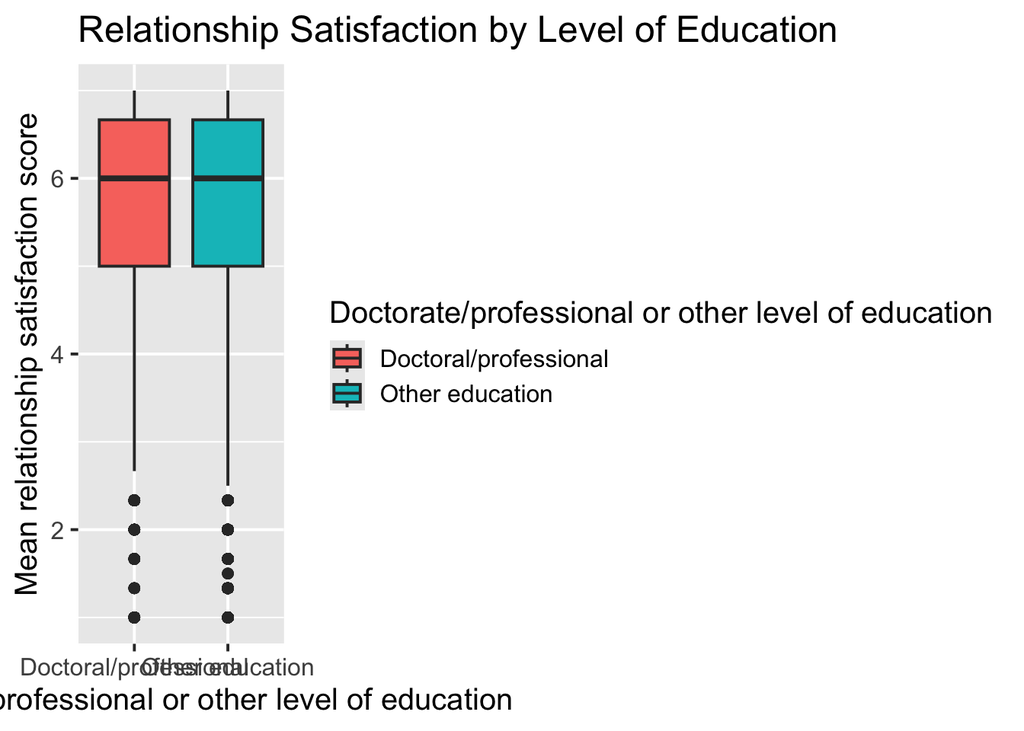

```r
#Box plot
#The line is the median; the box covers the middle 50% of responses (Q1-Q3).
#Whiskers reach the most extreme observations within 1.5 IQR of the box edges.
#Points beyond the whiskers are not necessarily errors.

h1Box <- ggplot(data=h1Data,
                aes(x=degreeGroup,
                    y=relSat,
                    fill=degreeGroup)) +
  geom_boxplot()+
  labs(x="Doctorate/professional or other level of education",
       y="Mean relationship satisfaction score",
       fill="Doctorate/professional or other level of education",
       title="Relationship Satisfaction by Level of Education")+
  theme_gray(base_size=15)

h1Box
```

## 3. H1 violin plot with boxplot

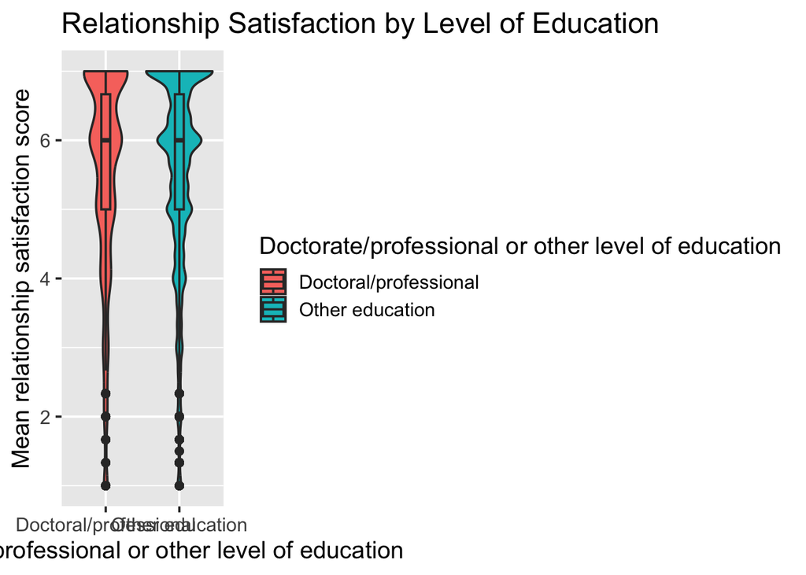

```r
#Violin Plot
#Wider sections show where responses are more concentrated within each group.
#The shape depends on smoothing; integer scores can create bumps.
#Violin width does not show group sample size. The box adds the median and IQR.

h1Viol <- ggplot(data=h1Data,
                 aes(x= degreeGroup,
                    y= relSat,
                    fill= degreeGroup))+
  geom_violin()+
  geom_boxplot(width=.12)+
labs(x="Doctorate/professional or other level of education",
       y="Mean relationship satisfaction score",
       fill="Doctorate/professional or other level of education",
       title="Relationship Satisfaction by Level of Education")+
  theme_gray(base_size=15)

h1Viol
```

## 4. H1 raincloud plot

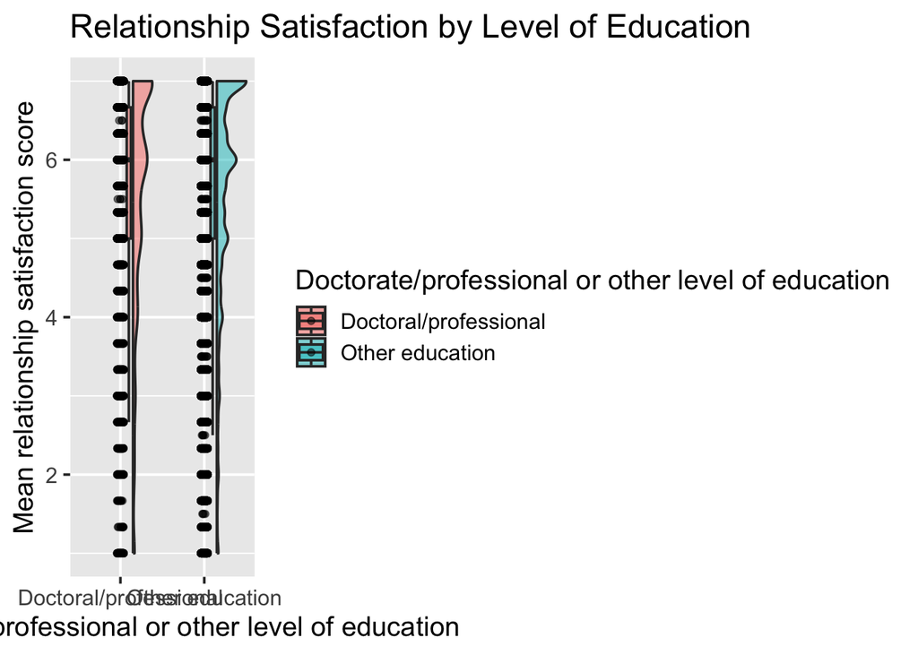

```r
# raincloud plot for h1

h1Rain <- ggplot(data=h1Data,
                 aes(x= degreeGroup,
                    y= relSat,
                    fill= degreeGroup))+
  geom_rain(alpha = .5)+
  labs(x= "Doctorate/professional or other level of education",
       y="Mean relationship satisfaction score",
       fill="Doctorate/professional or other level of education",
       title="Relationship Satisfaction by Level of Education")+
  theme_gray(base_size=15)

h1Rain
```

## 5. H2 scatter plot

```r
# check number of rows in h2 data

nrow(h2Data)
```

```
## [1] 23583
```

```r
nrow(unique(h2Data[,c("Time_A_hair_1","Time_social_media_1")]))
```

```
## [1] 9017
```

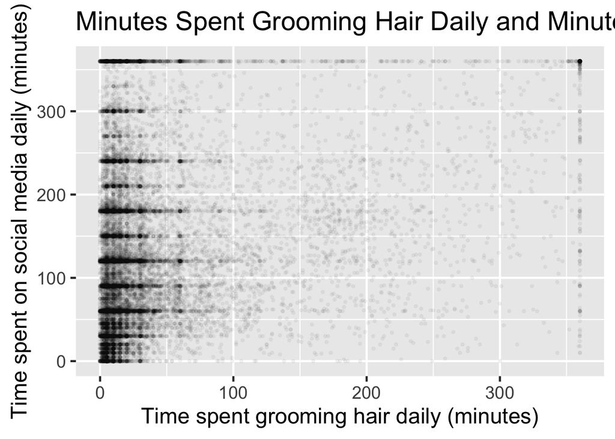

```r
# jitter scatterplot

h2Jitter <- ggplot(
  data=h2Data,
                    aes(x= Time_A_hair_1,
                        y= Time_social_media_1))+
    geom_jitter(width = .12,height=.04,alpha=.04,size = .6)+
    labs(x= "Time spent grooming hair daily (minutes)",
       y= "Time spent on social media daily (minutes)",
       title= "Minutes Spent Grooming Hair Daily and Minutes Spent on Social Media Daily")+
  theme_gray(base_size = 18)


h2Jitter
```

## 6. H2 jittered scatterplot with smooth line

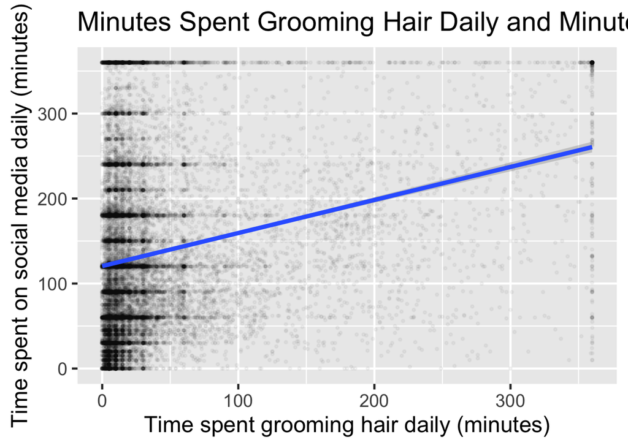

```r
# scatter Plot with line

h2Line <- h2Jitter + geom_smooth(method="lm")

h2Line
```

## 7. Save plots

```r
# Save PNG files in the project's figures folder

ggsave("figures/h1_raincloud.png",plot=h1Rain,width=10,height=6,dpi=300)
ggsave("figures/h2_scatter.png",plot=h2Line,width=10,height=6,dpi=300)
```

## 1. Load package

```r
library(psych)
```

## 2. Load data

```r
h1Data <- read.csv("processed_data/practice_h1.csv")
h2Data <- read.csv("processed_data/practice_h2.csv")
```

## 3. Look at distribution

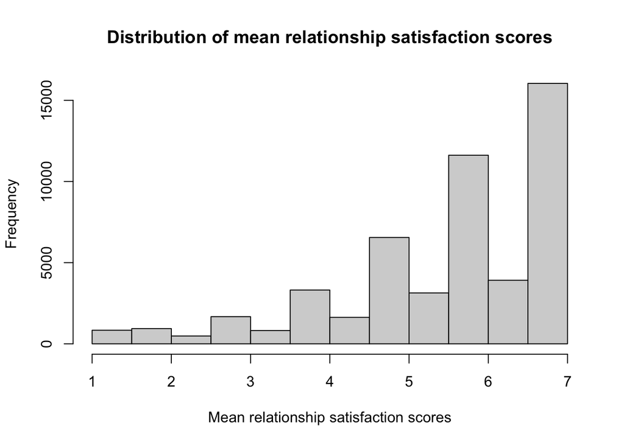

```r
# look at distributions with histograms and use readable labels

hist(h1Data$relSat,
     main = "Distribution of mean relationship satisfaction scores",
     xlab = "Mean relationship satisfaction scores")
```

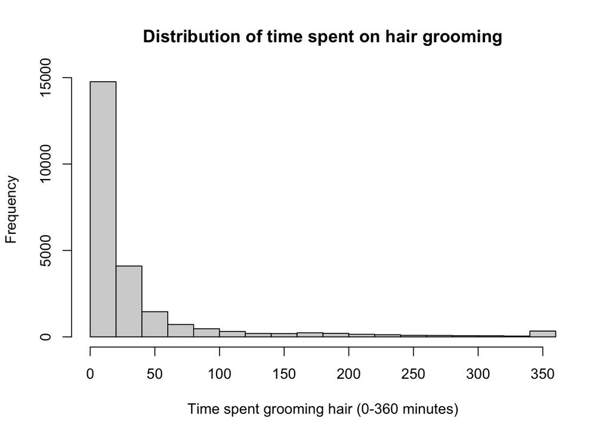

```r
hist(h2Data$Time_A_hair_1,
     main = "Distribution of time spent on hair grooming",
     xlab = "Time spent grooming hair (0-360 minutes)")
```

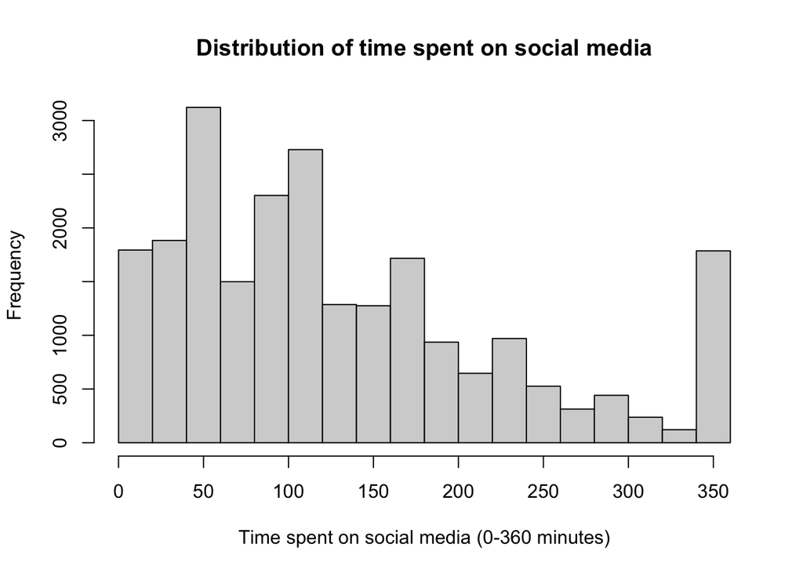

```r
hist(h2Data$Time_social_media_1,
     main = "Distribution of time spent on social media",
     xlab = "Time spent on social media (0-360 minutes)")
```

## 4. Stats one at a time

```r
# relSat mean, median, range, quartiles 1 & 3, number of people in each category, IQR

summary(h1Data$relSat, na.rm = TRUE)
```

```
##    Min. 1st Qu.  Median    Mean 3rd Qu.    Max.
##   1.000   5.000   6.000   5.588   6.667   7.000
```

```r
table(h1Data$relSat, useNA = "ifany")
```

```
##
##                1 1.33333333333333              1.5 1.66666666666667
##              639              193                4              244
##                2 2.33333333333333              2.5 2.66666666666667
##              694              477                5              515
##                3 3.33333333333333              3.5 3.66666666666667
##             1156              806               10              943
##                4 4.33333333333333              4.5 4.66666666666667
##             2371             1617               13             1957
##                5 5.33333333333333              5.5 5.66666666666667
##             4594             3116               18             3490
##                6 6.33333333333333              6.5 6.66666666666667
##             8129             3898               17             3500
##                7
##            12544
```

```r
IQR(h1Data$relSat, na.rm = TRUE)
```

```
## [1] 1.666667
```

```r
# Time_A_hair_1 mean, median, range, quartiles 1 & 3, number of people in each category, IQR

summary(h2Data$Time_A_hair_1, na.rm = TRUE)
```

```
##    Min. 1st Qu.  Median    Mean 3rd Qu.    Max.
##    0.00    7.00   15.00   36.83   31.00  360.00
```

```r
table(h2Data$Time_A_hair_1, useNA = "ifany")
```

```
##
##    0    1    2    3    4    5    6    7    8    9   10   11   12   13   14   15
##  320  378  636  694  682 2014  831  457  431  552 2287  680  488  354  431 1355
##   16   17   18   19   20   21   22   23   24   25   26   27   28   29   30   31
##  419  267  243  308  940  342  219  178  181  252  153  157  154  223  785  290
##   32   33   34   35   36   37   38   39   40   41   42   43   44   45   46   47
##  171  183  131  150   98   95   87   82  170   80   86   64   85  126   65   52
##   48   49   50   51   52   53   54   55   56   57   58   59   60   61   62   63
##   40   66   83   53   47   43   41   53   51   55   64   75  226   83   53   52
##   64   65   66   67   68   69   70   71   72   73   74   75   76   77   78   79
##   36   38   35   37   33   28   25   28   42   24   28   36   33   31   24   21
##   80   81   82   83   84   85   86   87   88   89   90   91   92   93   94   95
##   29   26   30   31   22   32   19   16   19   24   44   28   29   22   20   18
##   96   97   98   99  100  101  102  103  104  105  106  107  108  109  110  111
##   18   18   10   17   25   11   20   15   11   15   19   13   15   18   13   16
```

[output cut: 32 more lines]

```r
IQR(h2Data$Time_A_hair_1, na.rm = TRUE)
```

```
## [1] 24
```

```r
# Time_social_media_1 mean, median, range, quartiles 1 & 3, number of people in each category, IQR

summary(h2Data$Time_social_media_1, na.rm = TRUE)
```

```
##    Min. 1st Qu.  Median    Mean 3rd Qu.    Max.
##     0.0    60.0   120.0   134.9   181.0   360.0
```

```r
table(h2Data$Time_social_media_1, useNA = "ifany")
```

```
##
##    0    1    2    3    4    5    6    7    8    9   10   11   12   13   14   15
##  515   35   30   22   21  125   18    7   21   24  254   26   27   14   22  215
##   16   17   18   19   20   21   22   23   24   25   26   27   28   29   30   31
##   43   14   15   30  316   33   27   15   31   61   23   22   25   70  880   90
##   32   33   34   35   36   37   38   39   40   41   42   43   44   45   46   47
##   65   45   30   77   48   28   32   27  254   47   38   40   47  287   65   30
##   48   49   50   51   52   53   54   55   56   57   58   59   60   61   62   63
##   26   41  133   43   32   25   32   66   43   50   78  156 1843  354  115   92
##   64   65   66   67   68   69   70   71   72   73   74   75   76   77   78   79
##   53   66   64   45   36   41   68   47   44   36   39  122   49   39   34   39
##   80   81   82   83   84   85   86   87   88   89   90   91   92   93   94   95
##  116   58   30   40   39   65   46   50   69  112 1075  192   94   59   57   60
##   96   97   98   99  100  101  102  103  104  105  106  107  108  109  110  111
##   45   46   37   44   84   28   40   31   48   91   40   31   23   32   52   31
```

[output cut: 32 more lines]

```r
IQR(h2Data$Time_social_media_1, na.rm = TRUE)
```

```
## [1] 121
```

## 5. Standardize a variable

```r
# create standardized score column for relationship satisfaction

h1Data$relSatz <- as.numeric(scale(h1Data$relSat))
head(h1Data[, c("relSat", "relSatz")])
```

```
##     relSat    relSatz
## 1 4.500000 -0.7795940
## 2 5.333333 -0.1824164
## 3 5.000000 -0.4212874
## 4 6.000000  0.2953257
## 5 1.666667 -2.8099980
## 6 6.000000  0.2953257
```

```r
# check to see that the standardized scores have mean approximately 0 and standard deviation 1

mean(h1Data$relSatz, na.rm = TRUE)
```

```
## [1] 2.539937e-14
```

```r
sd(h1Data$relSatz, na.rm = TRUE)
```

```
## [1] 1
```

## 6. Covariance and correlation

```r
# covariance for h2.

cov(h2Data$Time_A_hair_1, h2Data$Time_social_media_1, use = "complete.obs")
```

```
## [1] 1549.639
```

```r
# Pearson correlation for h2

cor(h2Data$Time_A_hair_1, h2Data$Time_social_media_1, use = "complete.obs")
```

```
## [1] 0.2508325
```

```r
# define corData for h2

corData <- h2Data[, c("Time_A_hair_1", "Time_social_media_1")]

# correlation matrix to see correlation for each pair of columns in h2

cor(corData, use = "complete.obs")
```

```
##                     Time_A_hair_1 Time_social_media_1
## Time_A_hair_1           1.0000000           0.2508325
## Time_social_media_1     0.2508325           1.0000000
```

## 7. Another combined summary

```r
# use psych to look at descriptive stats for h2 corData

psych::describe(corData)
```

```
##                     vars     n   mean    sd median trimmed   mad min max range
## Time_A_hair_1          1 23583  36.83 63.12     15   20.90 14.83   0 360   360
## Time_social_media_1    2 23583 134.86 97.88    120  123.48 88.96   0 360   360
##                     skew kurtosis   se
## Time_A_hair_1       3.34    11.81 0.41
## Time_social_media_1 0.88    -0.04 0.64
```